### Bayesian Modeling for Socio-Environmental Data

#### August 04, 2016

#### Table of Contents

I. Motivation

II. Problem

III. Preliminaries

IV. Writing a sampler

V. Trace plots and plots of marginal posteriors

#### I. Motivation

This problem challenges you to understand how the wickedly clever Markov chain Monte Carlo algorithm takes a multivariate joint distribution and breaks it into a series of univariate, marginal distributions that can be approximated one at a time. There are only two unknowns in this problem, but the same principles and approach would apply if there were two hundred. The accompanying document, MCMCMath.pdf, describes the math that stands behind the coding that you will do here.

#### II. Problem

You will write code using conjugate relationships to draw samples from marginal posterior distributions of a mean and variance.

#### III. Preliminaries

1. Set the seed for random numbers = 1 in R with `set.seed(1)`.
2. Load the `actuar` library, which contains functions for inverse gamma distributions needed in step 4.
3. Simulate 100 data points from a normal distribution with mean $\theta = 100$ and variance $\varsigma^{2} = 25$ to first test the conjugate functions. Call the dataset `y`. Be careful here. R requires the standard deviation, not the variance, as a parameter. Simulating data is always a good way to test methods. Your method should be able to recover the generating parameters given a sufficiently large number of simulated observations.

```r
set.seed(1)
library(actuar)
varsigma.sq = 25
theta = 100
n = 100

y = rnorm(n, theta, sqrt(varsigma.sq))
```

4. Write functions that calculate the parameters of the posterior distributions for $\theta$ and $\varsigma^{2}$ where each parameter’s prior is the respective conjugate of the likelihood. This is explained more fully in MCMCMath.pdf, so study these functions relative to the math presented there.

```r
# normal likelihood with normal prior conjugate for mean, assuming variance
# is known mu_0 is prior mean sigma.sq_0 is prior variance of mean
# varsigma.sq is known variance of data

draw_mean = function(mu_0, sigma.sq_0, varsigma.sq, y) {
    mu_1 = ((mu_0/sigma.sq_0 + sum(y)/varsigma.sq))/(1/sigma.sq_0 + length(y)/varsigma.sq)
    sigma.sq_1 = 1/(1/sigma.sq_0 + length(y)/varsigma.sq)
    z = rnorm(1, mu_1, sqrt(sigma.sq_1))
    param = list(z = z, mu_1 = mu_1, sigma.sq_1 = sigma.sq_1)
    return(param)
}

# normal likelihood with gamma prior conjugate relationship for variance,
# assuming mean is known alpha_0 is parameter of prior for variance beta_0
# is parameter of prior for variance

draw_var = function(alpha_0, beta_0, theta, y) {
    alpha_1 = alpha_0 + length(y)/2
    beta_1 = beta_0 + sum((y - theta)^2)/2
    z = rinvgamma(1, alpha_1, scale = beta_1)
    param = list(z = z, alpha_1 = alpha_1, beta_1 = beta_1)
    return(param)
}
```

#### IV. Writing a sampler

Now execute these steps:

1. Set up a matrix for storing samples from the posterior distribution of the mean. The number of rows should equal the number of chains (3) and number of columns should equal to the number of iterations (10,000). Do the same thing for storing samples from the posterior distribution of the variance.

```r
n.iter = 10000
n.chains = 3
pvar = matrix(nrow = n.chains, ncol = n.iter)
pmean = matrix(nrow = n.chains, ncol = n.iter)
```

2. Assign initial values to the first column of each matrix, a different value for each of the chains. These can be virtually any value within the support of the random variable.

```r
pmean[1:3, 1] = c(50, 20, 1)
pvar[1:3, 1] = c(10, 5, 0.1)
```

3. Set up nested `for` loops to iterate from one to the total number of iterations for each of the three chains. Use the conjugate functions `draw_mean` and `draw_var` to draw a sample from the distribution of the mean using the value of the variance at the current iteration. Then make a draw from the variance using the current value of the mean. Repeat. Assume vague priors for the mean and variance:

$$[\,\theta\,] = \textrm{normal}(\,\theta \mid (0, 1000\,)$$
$$[\,\varsigma^{2}\,] = \textrm{inverse gamma}(\,\varsigma^{2} \mid .001, .001\,)$$

```r
for (t in 2:n.iter) {
    for (j in 1:n.chains) {
        pmean[j, t] = draw_mean(mu_0 = 0, sigma.sq_0 = 1000, varsigma.sq = pvar[j,
            t - 1], y = y)$z
        pvar[j, t] = draw_var(alpha_0 = 0.001, beta_0 = 0.001, theta = pmean[j,
            t], y = y)$z
    }
}
```

#### V. Trace plots and plots of marginal posteriors

1. Discard the first 1000 iterations as the burn-in. On the same figure, plot the value of the mean as a function of iteration number for each chain. This is called a trace plot.

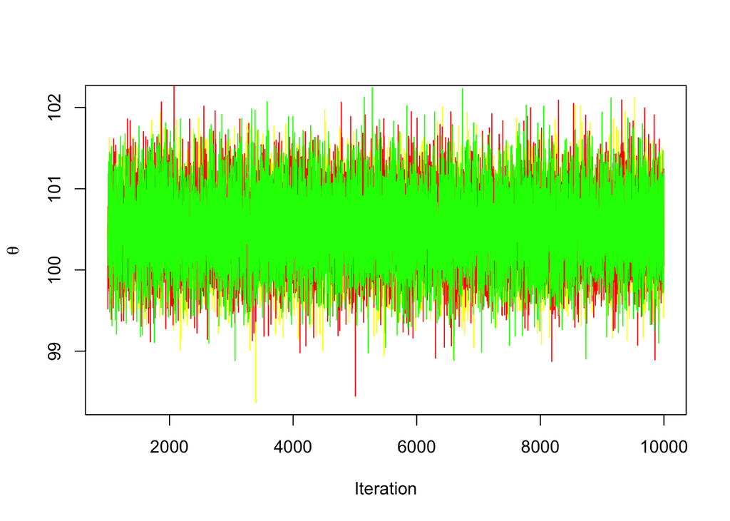

```r
burnin = 1000
samplesKept <- (burnin + 1):n.iter

plot(samplesKept, pmean[1, samplesKept], typ = "l", ylab = expression(theta),
    xlab = "Iteration", col = "yellow")
lines(samplesKept, pmean[2, samplesKept], typ = "l", col = "red")
lines(samplesKept, pmean[3, samplesKept], typ = "l", col = "green")
```

2. For all chains combined, make a histogram of the samples retained after burn-in. Put a vertical line on the plot showing the generating value.

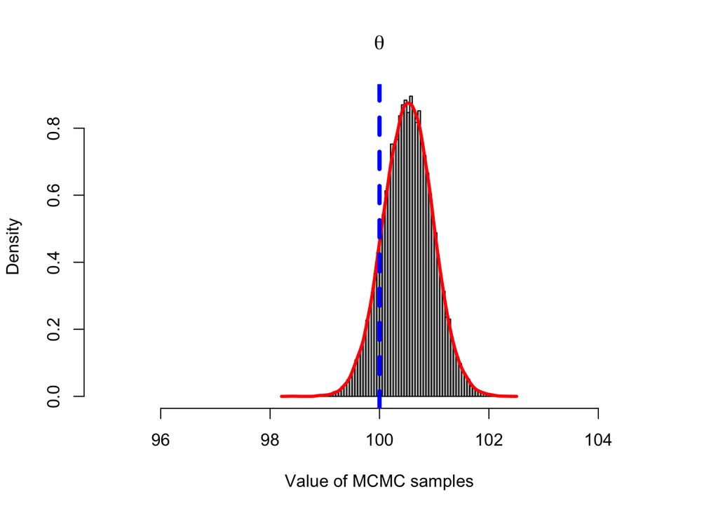

```r
hist(pmean[, samplesKept], breaks = 100, freq = FALSE, main = expression(theta),
    xlim = c(95, 105), xlab = "Value of MCMC samples", col = "gray")
lines(density(pmean[, samplesKept]), col = "red", lwd = 3)
abline(v = theta, lty = "dashed", col = "blue", lwd = 4)
```

3. Repeat steps 1-2 for the variance.

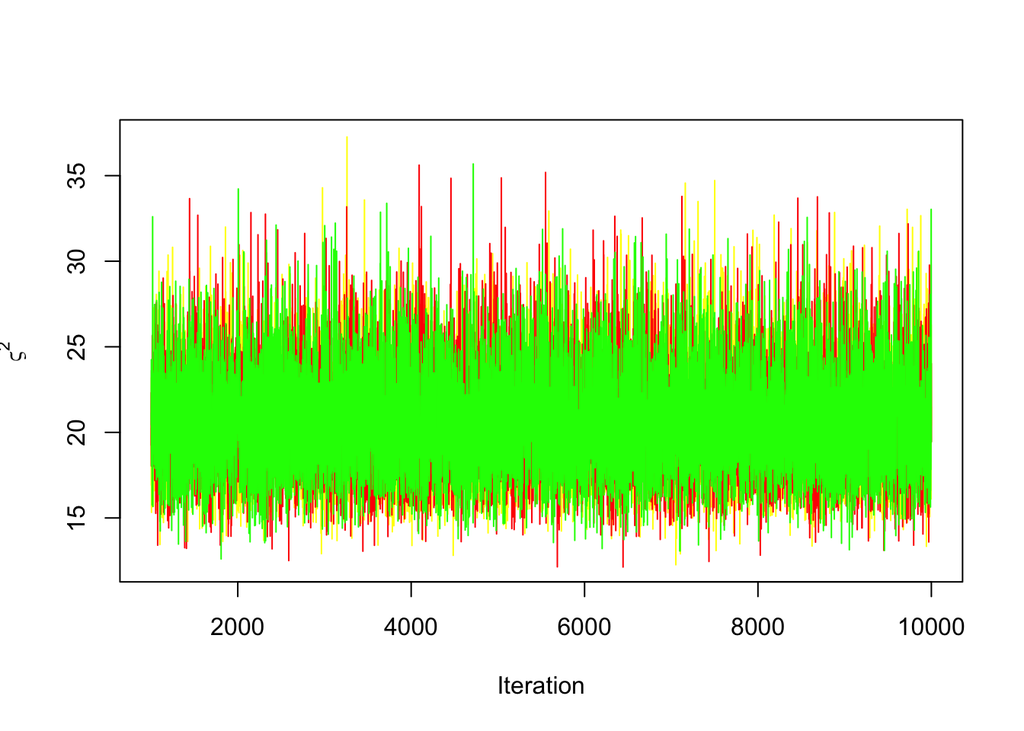

```r
plot(samplesKept, pvar[1, samplesKept], typ = "l", ylab = expression(varsigma^2),
    xlab = "Iteration", col = "yellow")
lines(samplesKept, pvar[2, samplesKept], typ = "l", col = "red")
lines(samplesKept, pvar[3, samplesKept], typ = "l", col = "green")
```

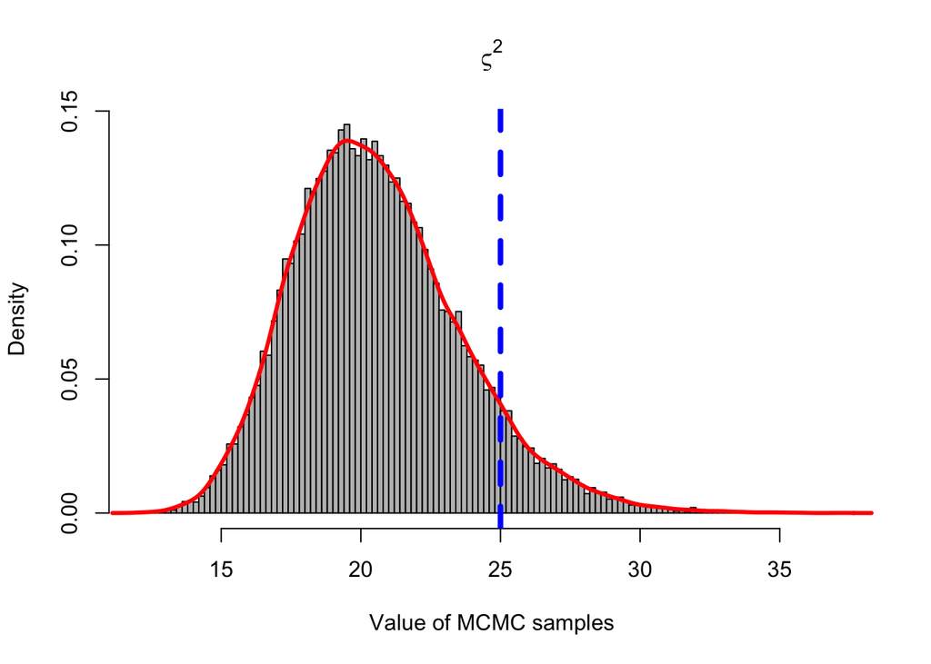

```r
hist(pvar[, samplesKept], breaks = 100, freq = FALSE, main = expression(varsigma^2),
    xlab = "Value of MCMC samples", col = "gray")
lines(density(pvar[, samplesKept]), col = "red", lwd = 3)
abline(v = varsigma.sq, lty = "dashed", col = "blue", lwd = 4)
```

4. For both $\theta$ and $\varsigma^{2}$, calculate the mean of all the chains combined and its standard deviation. Interpret these quantities.

```r
mean(pmean[, samplesKept])
```

```
## [1] 100.5222
```

```r
sd(pmean[, samplesKept])
```

```
## [1] 0.4517329
```

```r
mean(pvar[, samplesKept])
```

```
## [1] 20.60513
```

```r
sd(pvar[, samplesKept])
```

```
## [1] 3.007686
```

5. Compare the standard deviation of the posterior distribution of $\theta$ with an approximation using the standard deviation of the data divided by the square root of the sample size (what is this quantity called?). Don’t worry if these don’t match when the sample size is less than 1000.

```r
sd(y)/sqrt(length(y))
```

```
## [1] 0.4490997
```

6. Vary the number of values in the simulated dataset, e.g., n = 10,100,1000. What happens to the mean and variance of the posterior distributions as n gets large? We do not recover the generating values of $\theta$ and $\varsigma^{2}$ when $n$ is small. Why?
7. Make the burnin = 1 instead of 1000. Does this change your results? Why or why not?
8. Reverse the order of the conjugate functions in step IV.3 so that the variance is drawn first followed by the mean. Does this reordering have an effect on your choice of burnin? Why or why not?